# MALASPINA SRF | 16S amplicons | Chloroplasts and cyanobacteria

Logares R. & Rubinat-Ripoll L.

24.01.2015

# 1) Data overview

Samples with less than 5000 reads are removed:

```
## MD2304 MD2332 MD2695 MD2926
##   2738   3446    425    627
```

Table dimensions and content outline:

```
## [1] 1306  119
```

```
##          MD1013 MD1035 MD1042 MD1080 MD1100
## OTU_5       162    238    486   1639    653
## OTU_1     13804   9239  37085  24192  36066
## OTU_596      20     75    100    502    118
## OTU_1295      1      1      7      1      0
## OTU_36       59    196    210    346     33
```

Minimum number of reads per station:

```r
min(colSums(otu_tb16_cc_min5000_v2))
```

```
## [1] 5862
```

Maximum number of reads per station:

```r
max(colSums(otu_tb16_cc_min5000_v2))
```

```
## [1] 156830
```

Identification of station with higher number of reads:

```r
amplicons_per_sample_cc<-colSums(otu_tb16_cc_min5000_v2)
amplicons_per_sample_cc[which(colSums(otu_tb16_cc_min5000_v2)>155000)]
```

```
##  MD897
## 156830
```

Overall reads per sample:

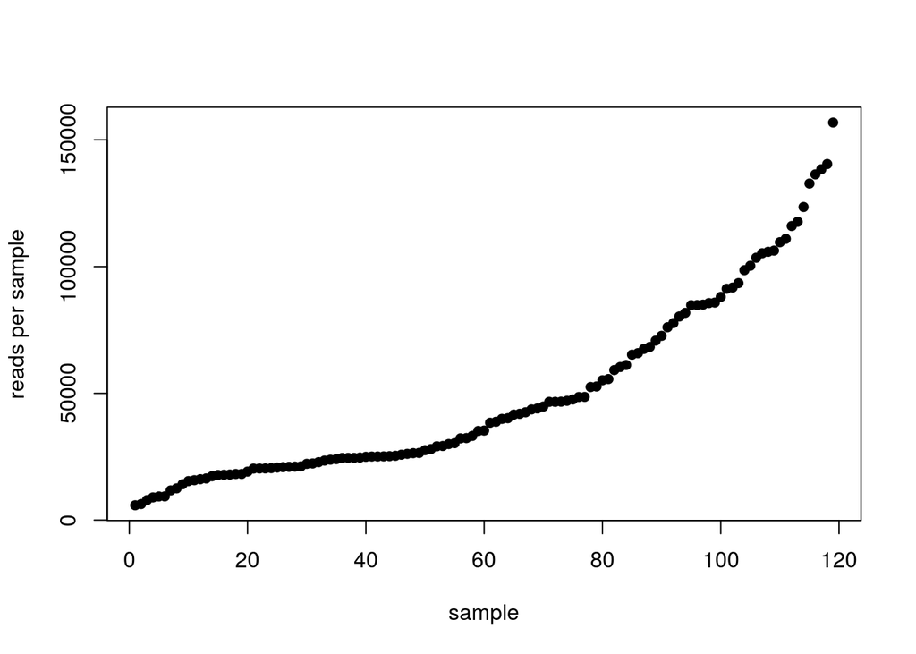

# 2) Normalization to 5000 reads per sample

Let’s normalize the original dataset by randomly subsampling 5000 reads in each station:

```r
library(vegan)
otu_tb16_cc_min5000_v2_t<-t(otu_tb16_cc_min5000_v2)
otu_tb16_cc_t_ss5000<-rrarefy(otu_tb16_cc_min5000_v2_t, 5000)
```

The normalized table shows the following dimensions and format:

```
## [1]  119 1306
```

```
##        OTU_5 OTU_1 OTU_596 OTU_1295 OTU_36
## MD1013    38  2706       2        0     11
## MD1035    41  1602      15        0     35
## MD1042    40  2558       6        0     16
## MD1080    52   912      17        0      8
## MD1100    31  2095      11        0      2
```

Its content fits with the expected normalization values (5000 reads per station):

```r
rowSums(otu_tb16_cc_t_ss5000)
```

```
## MD1013 MD1035 MD1042 MD1080 MD1100  MD111 MD1125 MD1143 MD1176 MD1186
##   5000   5000   5000   5000   5000   5000   5000   5000   5000   5000
## MD1209 MD1222 MD1246 MD1254 MD1260 MD1293 MD1302 MD1318 MD1324 MD1331
##   5000   5000   5000   5000   5000   5000   5000   5000   5000   5000
## MD1354 MD1368 MD1398  MD141 MD1421 MD1425 MD1459 MD1475 MD1479 MD1490
##   5000   5000   5000   5000   5000   5000   5000   5000   5000   5000
## MD1517 MD1537 MD1559 MD1589 MD1607 MD1629 MD1672 MD1700 MD1724 MD1744
##   5000   5000   5000   5000   5000   5000   5000   5000   5000   5000
## MD1772 MD1798 MD1811 MD1857 MD1885 MD1887 MD1928 MD1956 MD1964  MD196
##   5000   5000   5000   5000   5000   5000   5000   5000   5000   5000
## MD2004 MD2008  MD202 MD2047 MD2051 MD2094 MD2111  MD214 MD2151 MD2155
##   5000   5000   5000   5000   5000   5000   5000   5000   5000   5000
## MD2215 MD2243 MD2247 MD2340 MD2380 MD2408 MD2436 MD2448 MD2474 MD2516
##   5000   5000   5000   5000   5000   5000   5000   5000   5000   5000
##  MD254 MD2562 MD2594 MD2624 MD2662  MD266 MD2723 MD2751 MD2761 MD2821
##   5000   5000   5000   5000   5000   5000   5000   5000   5000   5000
##  MD285 MD2864   MD28 MD2956 MD2973  MD311  MD346  MD366  MD389   MD40
##   5000   5000   5000   5000   5000   5000   5000   5000   5000   5000
##  MD417  MD439  MD458  MD486  MD506  MD528   MD52  MD550  MD575  MD591
##   5000   5000   5000   5000   5000   5000   5000   5000   5000   5000
##   MD60  MD621  MD646   MD64  MD664  MD684  MD712  MD734  MD753  MD778
##   5000   5000   5000   5000   5000   5000   5000   5000   5000   5000
##  MD806  MD834  MD854  MD876  MD897  MD916  MD940  MD962   MD98
##   5000   5000   5000   5000   5000   5000   5000   5000   5000
```

Let’s check out how many OTUs don’t appear in the new table:

```r
length(which(colSums(otu_tb16_cc_t_ss5000)==0))
```

```
## [1] 170
```

There are 170 OTUs that don’t show any occurrence in the normalized data. Let’s remove them from the table and take a look at its final dimensions:

```r
otu_tb16_cc_t_ss5000_no_cero<-otu_tb16_cc_t_ss5000[,-(which(colSums(otu_tb16_cc_t_ss5000)==0))]
dim(otu_tb16_cc_t_ss5000_no_cero)
```

```
## [1]  119 1136
```

Datasets summary:

otu_tb16_cc_min5000_v2_t –> 119 1306

otu_tb16_cc_t_ss5000_no_cero –> 119 1136

# 3) General community analysis

## 3.1) Richness and evenness (Shannon index)

Most of the samples take Shannon Index values between 2.25 and 3.25:

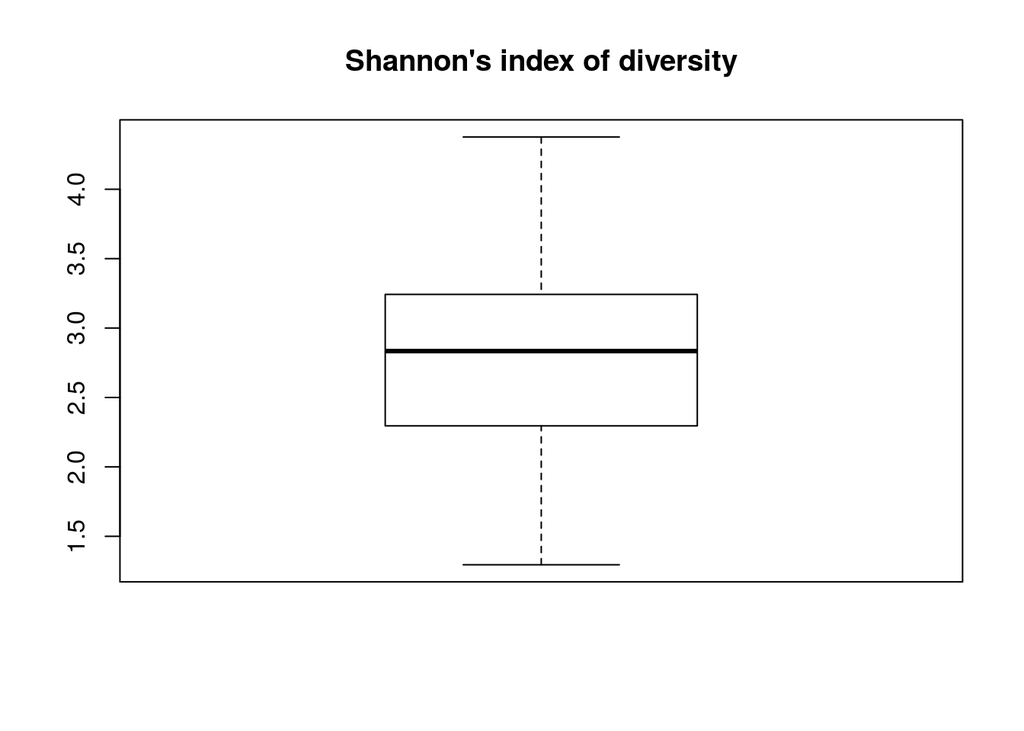

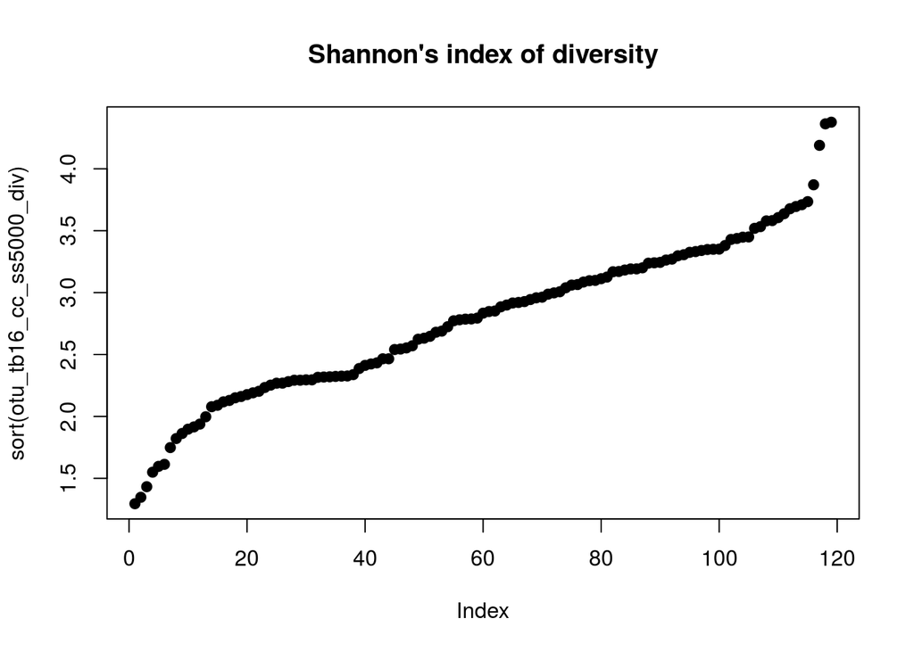

## 3.2) Richness: OTU number

Lowest number of OTUs per sample:

```
## [1] 134
```

Maximum number of OTUs per sample:

```
## [1] 379
```

In most of the samples, we can identify between 200 and 250 OTUs:

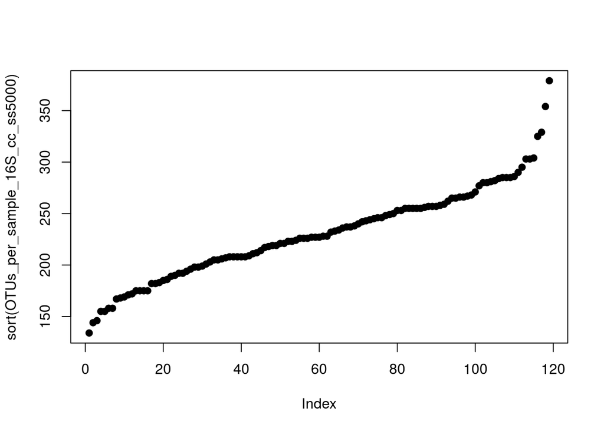

```r
plot(sort(OTUs_per_sample_16S_cc_ss5000), pch=19)
```

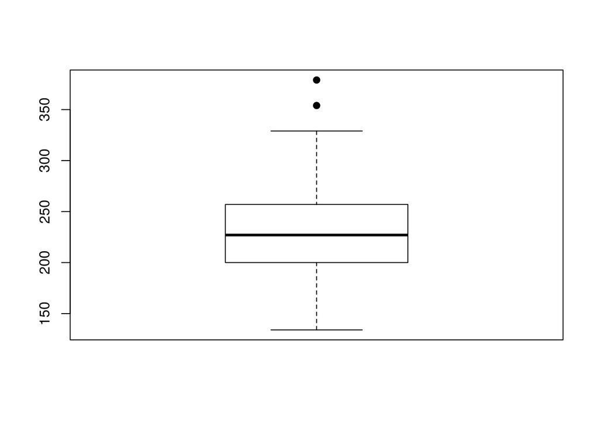

```r
boxplot(OTUs_per_sample_16S_cc_ss5000, pch=19)
```

## 3.3) Index of evenness

### 3.3.1) Pielou’s index

```r
pielou_evenness_16S_cc_ss5000 <- otu_tb16_cc_ss5000_div/log(OTUs_per_sample_16S_cc_ss5000)
```

The Pielou index (constrained between 0 and 1) takes values closer to 1 as the variation of species proportion in a sample decreases. Most of our samples get values between 0.425 and 0.6, meaning that the numerical composition of different OTUs within our samples is relatively similar:

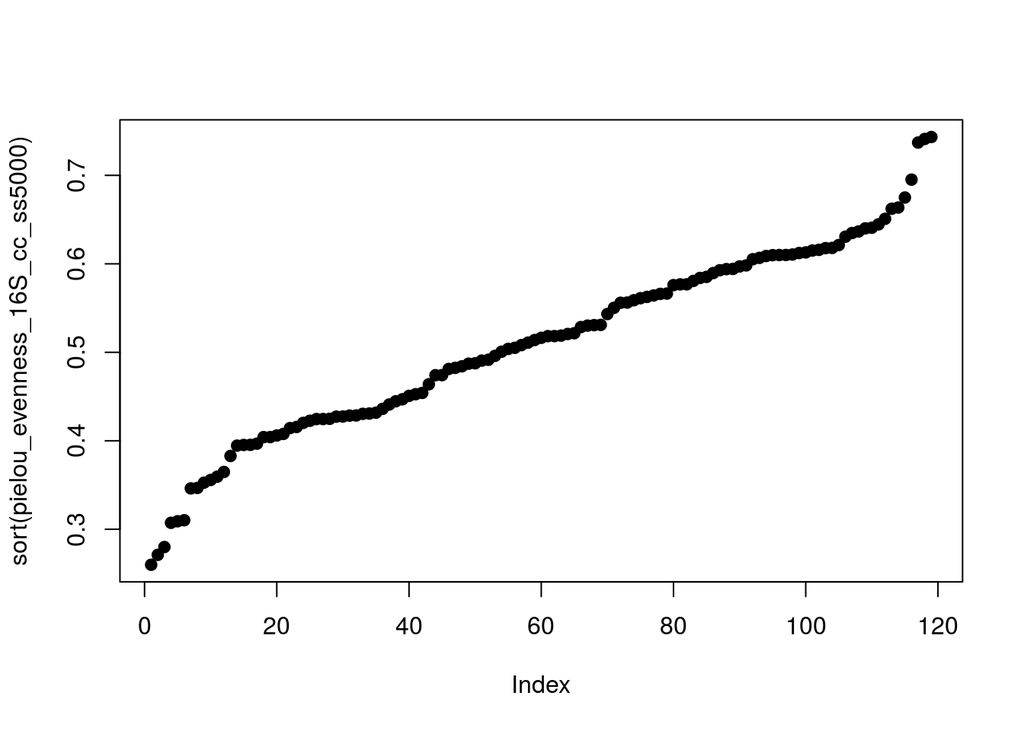

```r
plot(sort(pielou_evenness_16S_cc_ss5000), pch=19)
```

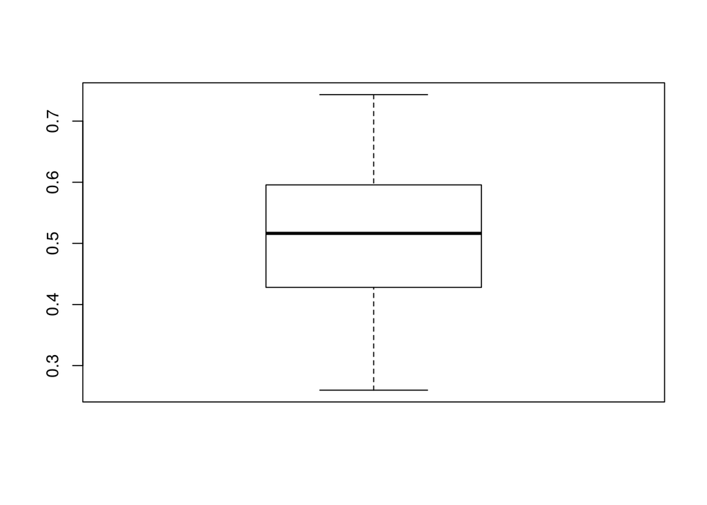

```r
boxplot(pielou_evenness_16S_cc_ss5000, pch=19)
```

```r
head(sort(colSums(otu_tb16_cc_t_ss5000_no_cero), decreasing=T), n=10L)
```

```
##   OTU_1   OTU_2   OTU_4   OTU_5   OTU_3   OTU_6 OTU_552  OTU_10  OTU_23
##  239049   84966   29934   23382   10547    9498    5997    5918    5373
## OTU_435
##    5360
```

Most of the OTUs show few occurrences, but we don’t observe the presence of a massive group of rare OTUs:

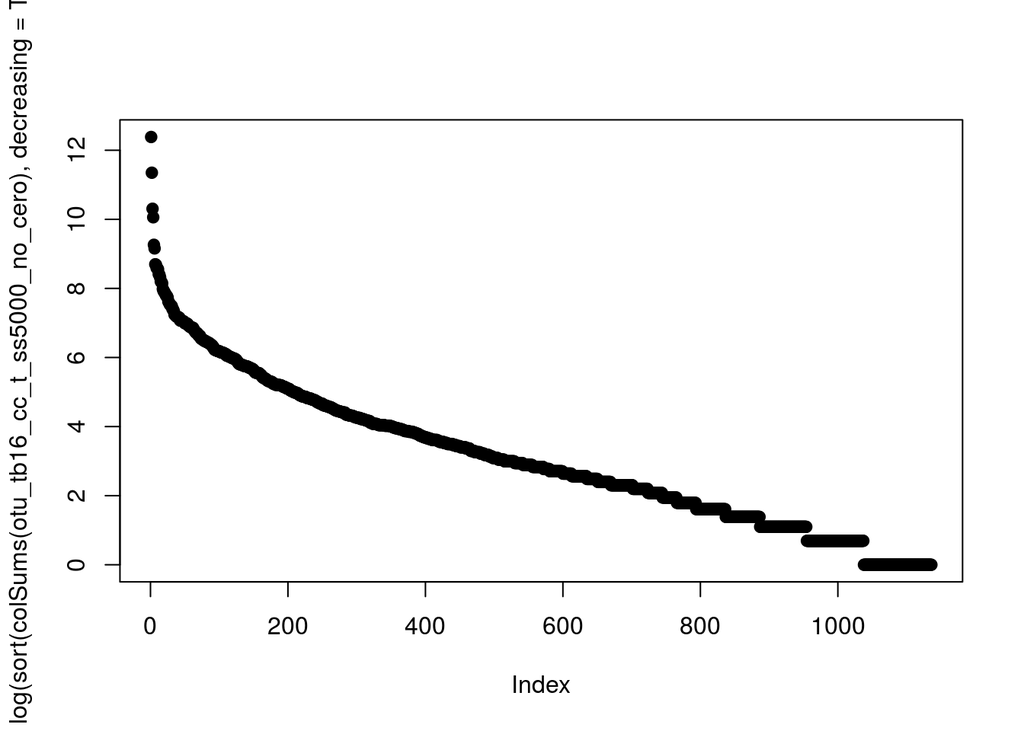

```r
plot(log(sort(colSums(otu_tb16_cc_t_ss5000_no_cero), decreasing=T)), pch=19)
```

## 3.4) Abundance Models

### 3.4.1) Rank-Abundance or Dominance/Diversity Model (“radfit”)

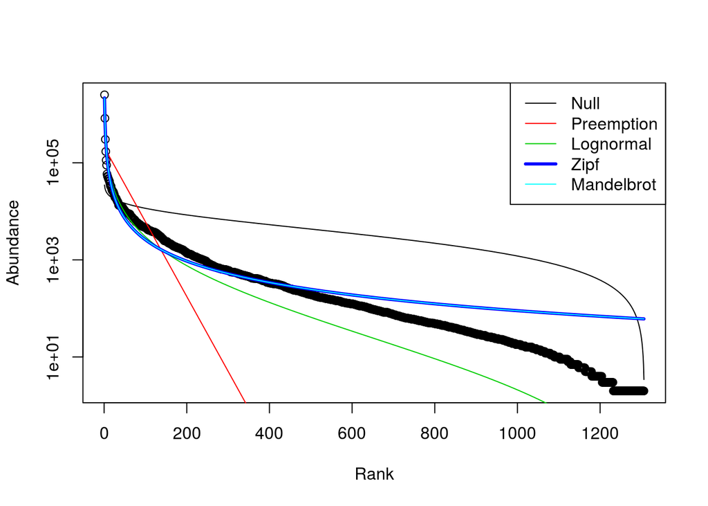

### 3.4.2) Preston’s Lognormal Model

According to Preston’s lognormal model fit into species frequencies groups, we’re missing ~65 species:

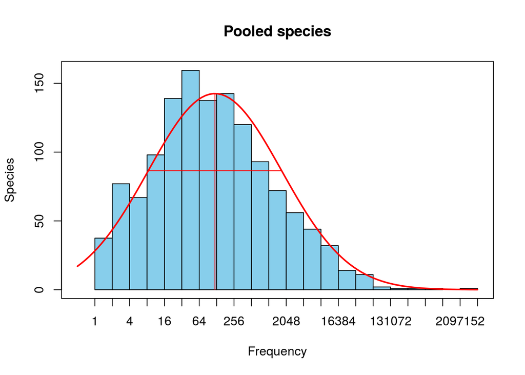

```r
otu_tb16_cc_min5000_prestonfit<-prestonfit(colSums(otu_tb16_cc_min5000_v2_t))
plot(otu_tb16_cc_min5000_prestonfit, main="Pooled species")
```

```r
veiledspec(otu_tb16_cc_min5000_prestonfit)
```

```
## Extrapolated     Observed       Veiled
##   1370.63659   1306.00000     64.63659
```

When computing Preston’s lognormal model fit without pooling data into groups, we only seem to miss ~23 species:

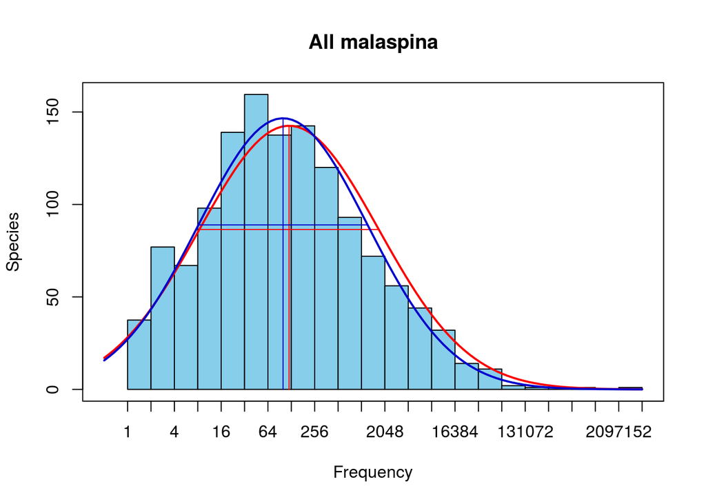

```
## Extrapolated     Observed       Veiled
##   1328.89313   1306.00000     22.89313
```

## 3.6) Beta diversity

### 3.6.1) Dissimilarity matrix using Bray-Curtis index:

The Bray-Curtis dissimilarity, constrained between 0 (minimum distance) and 1 (highest dissimilarity) allows us to quantify the differences between samples according to the composition and relative abundance of their OTUs. In our dataset, most of the samples pairs take dissimilarity values between 0.25 and 0.5, meaning that their composition is quiet similar.

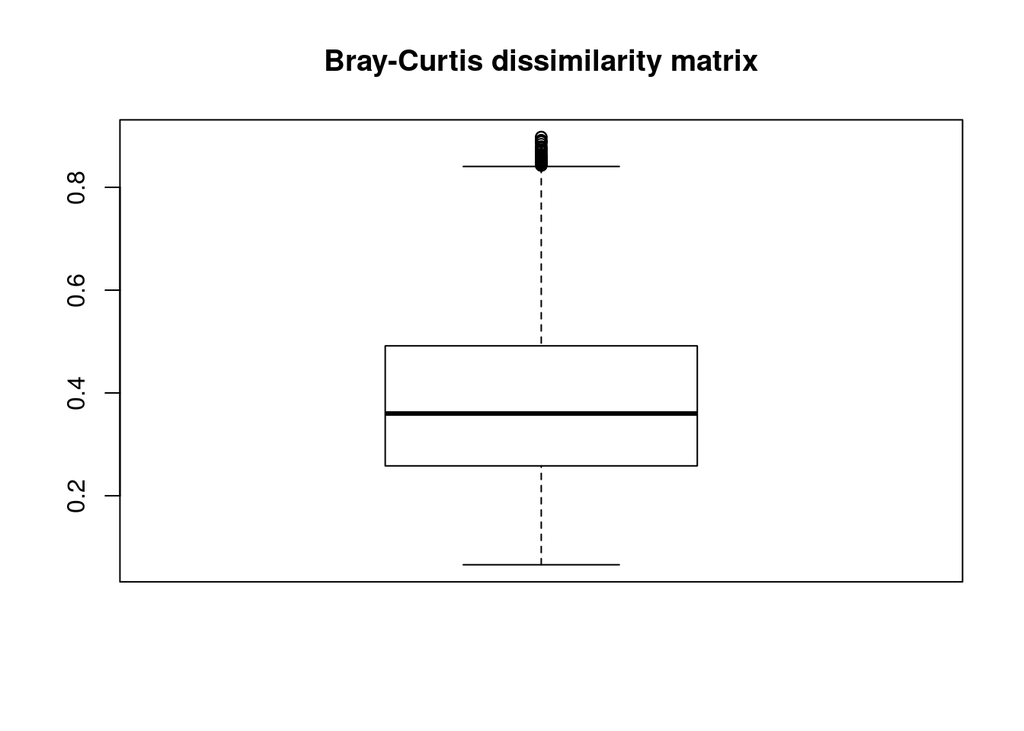

### 3.6.2) Hierarchical clustering

The only relatively evident clusters we can distinguish in the dendogram stand out in the very left side of the plot.

(To be done: assign Longhurst provinces information to each station and check if any of the central clusters is meaningful regarding to the samples’ geographical ubication)

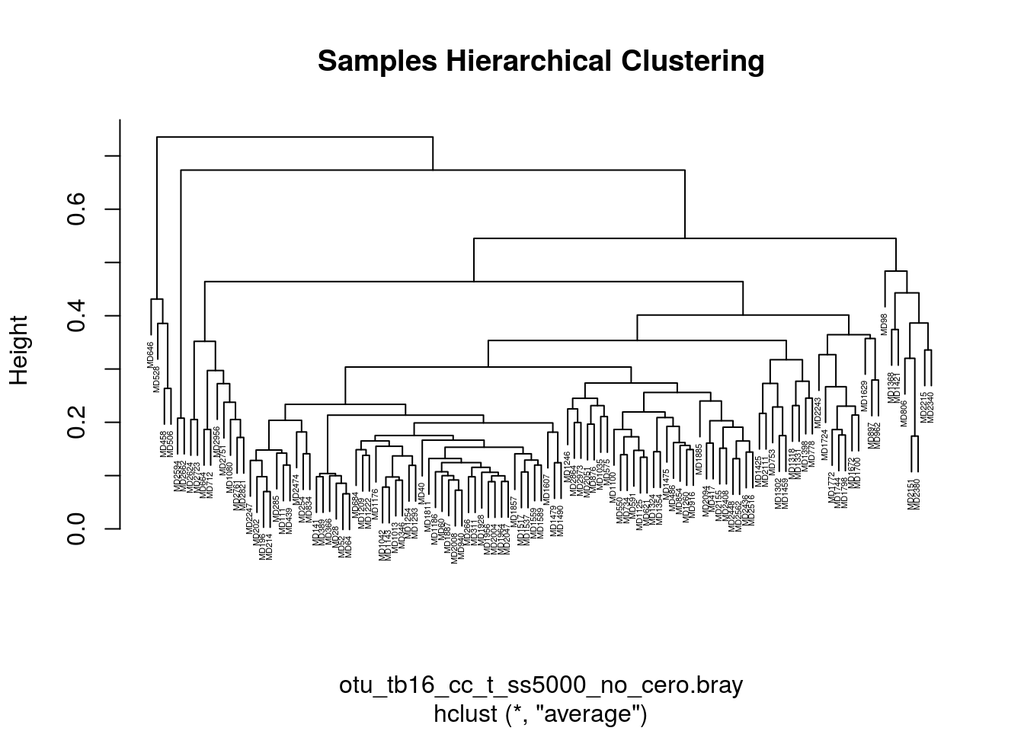

### 3.6.3) Non-metric multidimensional scaling

We can identify a prominent group in the middle-left side of the NMDS and a few isolated samples in the right edge of the plot. Considering the overall distribution, we’re not able to identify any informative clustering pattern.

The stress parameter takes a value below 0.3, meaning that the plot is valid.

```
##
## Call:
## monoMDS(dist = otu_tb16_cc_t_ss5000_no_cero.bray)
##
## Non-metric Multidimensional Scaling
##
## 119 points, dissimilarity 'bray', call 'vegdist(x = otu_tb16_cc_t_ss5000_no_cero, method = "bray")'
##
## Dimensions: 2
## Stress:     0.1352671
## Stress type 1, weak ties
## Scores scaled to unit root mean square, rotated to principal components
## Stopped after 85 iterations: Stress nearly unchanged (ratio > sratmax)
```

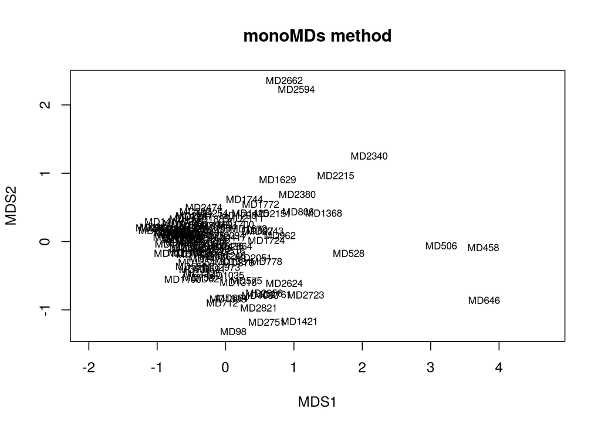

When implementing a most robut function for computing NMDS plots, the result is quiet the same:

```
## ... procrustes: rmse 0.02456737  max resid 0.1907394
## ... procrustes: rmse 0.01345761  max resid 0.09309577
## ... procrustes: rmse 0.01342349  max resid 0.09305948
## ... procrustes: rmse 0.009072358  max resid 0.08995759
## ... procrustes: rmse 0.009378952  max resid 0.06829526
## ... procrustes: rmse 0.0001779219  max resid 0.00131065
## *** Solution reached
```

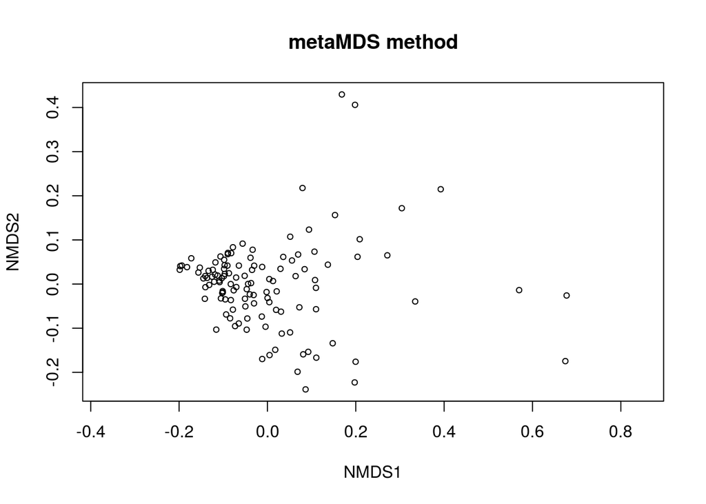

# 4) Geographical analysis

Working datasets:

1. Community matrix: otu_tb16_cc_t_ss5000_no_cero

```r
dim(otu_tb16_cc_t_ss5000_no_cero)
```

```
## [1]  119 1136
```

```r
otu_tb16_cc_t_ss5000_no_cero[1:5, 1:5]
```

```
##        OTU_5 OTU_1 OTU_596 OTU_1295 OTU_36
## MD1013    38  2706       2        0     11
## MD1035    41  1602      15        0     35
## MD1042    40  2558       6        0     16
## MD1080    52   912      17        0      8
## MD1100    31  2095      11        0      2
```

2. Community Bray-Curtis: otu_tb16_cc_t_ss5000_no_cero.bray

```r
otu_tb16_cc_t_ss5000_no_cero.bray<-as.matrix(otu_tb16_cc_t_ss5000_no_cero.bray)
```

3. Stations distances in km: geo_distances_MP_16S_cc_ss5000

```r
dim(geo_distances_MP_16S_cc_ss5000)
```

```
## [1] 119 119
```

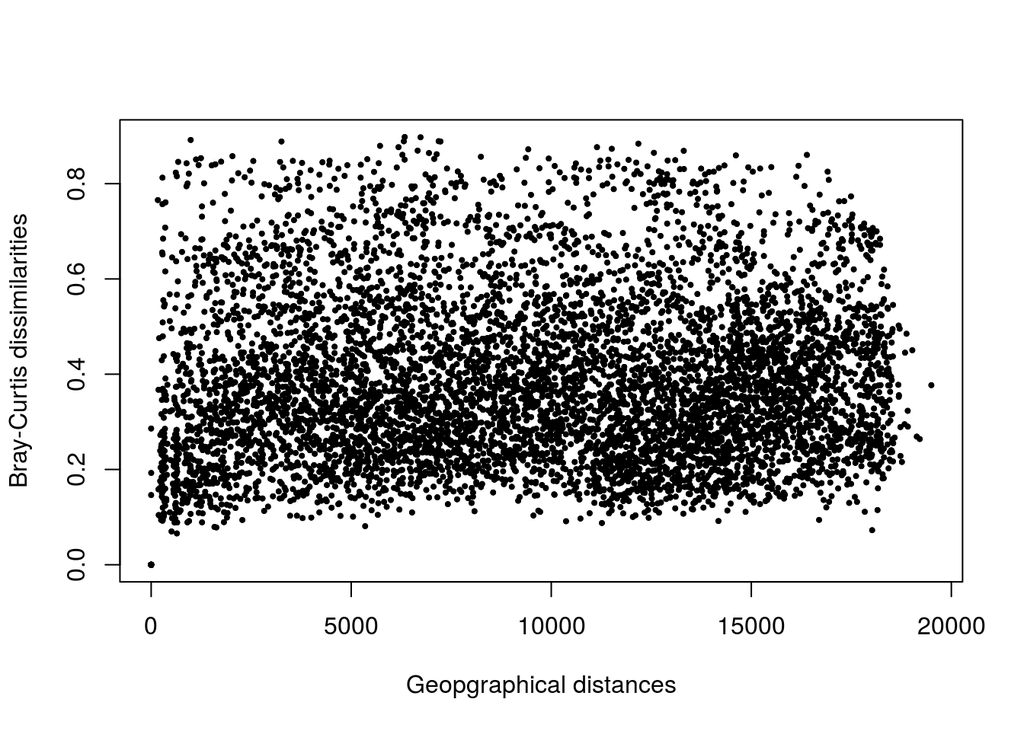

```r
plot(geo_distances_MP_16S_cc_ss5000, otu_tb16_cc_t_ss5000_no_cero.bray, pch=19, cex=0.4, xlab="Geopgraphical distances", ylab="Bray-Curtis dissimilarities")
```

## 4.1) Mantel correlograms

When implementing the Mantel Test, we obtain a very low statistic, meaning that the correlation between samples dissimilarity and geographical distances is weak; besides, it is not significant, so we shouldn’t consider the test meaningful.

```r
mantel(geo_distances_MP_16S_cc_ss5000, otu_tb16_cc_t_ss5000_no_cero.bray)
```

```
##
## Mantel statistic based on Pearson's product-moment correlation
##
## Call:
## mantel(xdis = geo_distances_MP_16S_cc_ss5000, ydis = otu_tb16_cc_t_ss5000_no_cero.bray)
##
## Mantel statistic r: 0.02022
##       Significance: 0.109
##
## Upper quantiles of permutations (null model):
##    90%    95%  97.5%    99%
## 0.0216 0.0296 0.0359 0.0419
## Permutation: free
## Number of permutations: 999
```

Maximum distance between samples:

```
## [1] 19500.19
```

Minimum distance between samples:

```
## [1] 0
```

Correlograms:

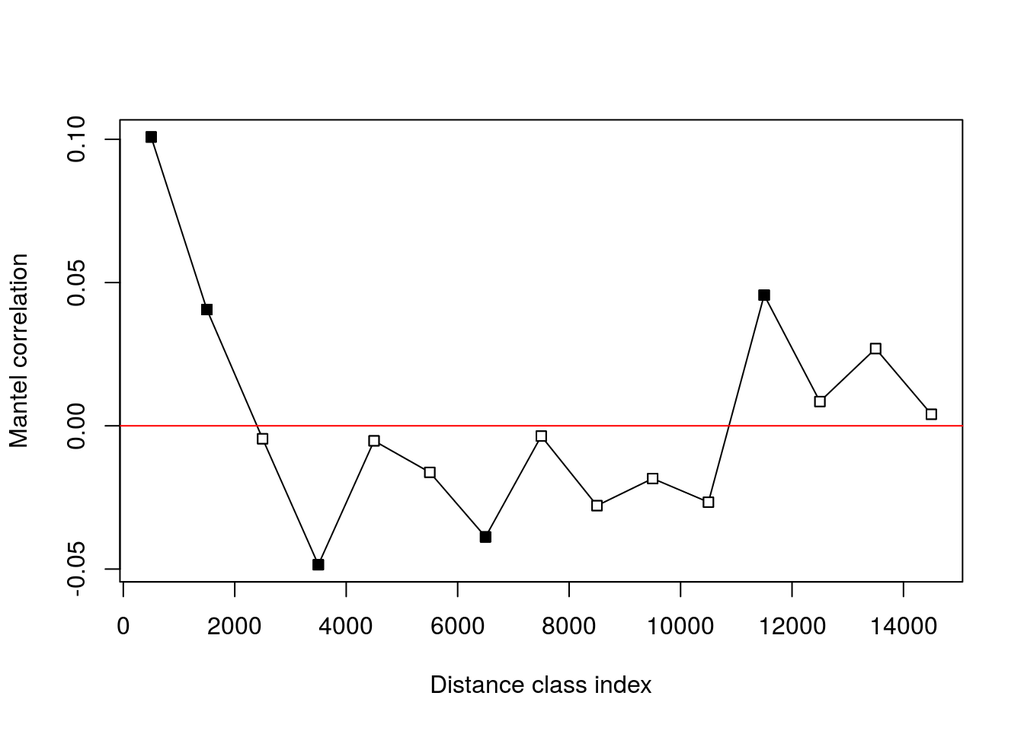

```r
MP_16s_cc_ss5000_mantel_correl_by_1000km<-mantel.correlog(otu_tb16_cc_t_ss5000_no_cero.bray, D.geo=geo_distances_MP_16S_cc_ss5000, break.pts=seq(0,20000, by=1000))
plot(MP_16s_cc_ss5000_mantel_correl_by_1000km)
```

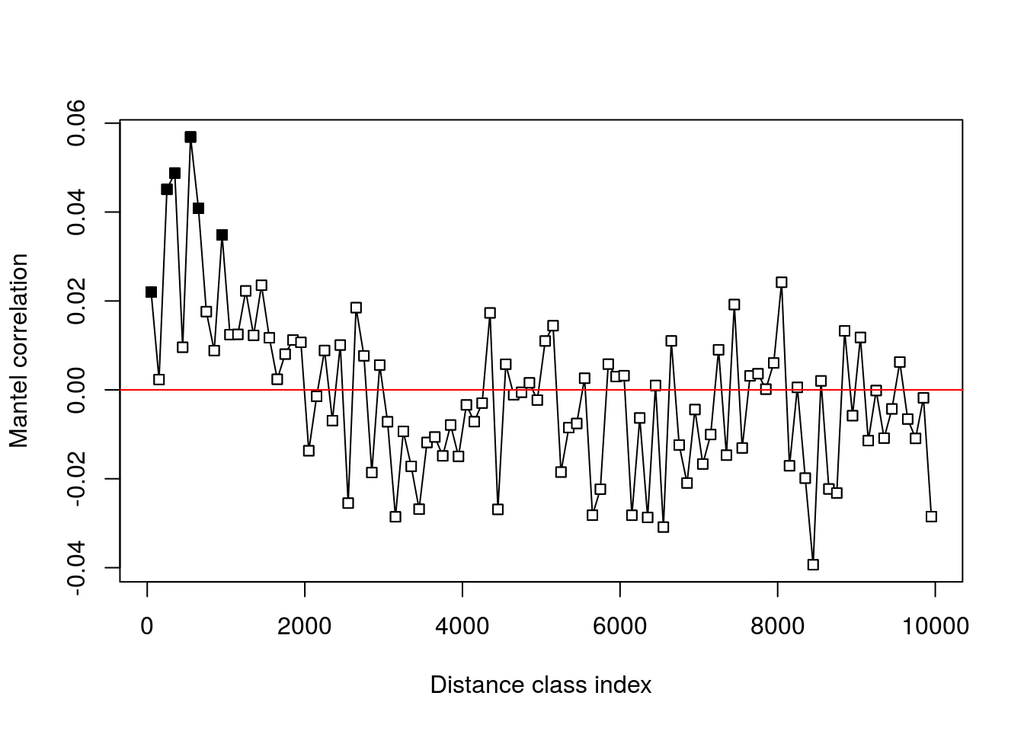

```r
MP_16s_cc_ss5000_mantel_correl_by_100km<-mantel.correlog(otu_tb16_cc_t_ss5000_no_cero.bray, D.geo=geo_distances_MP_16S_cc_ss5000, break.pts=seq(0,20000, by=100))
plot(MP_16s_cc_ss5000_mantel_correl_by_100km)
```

# 5) Abundance & occurence

In the following plot, we can appreciate the OTUs distribution according to their percentage of occurence and relative abundance. The red line keeps up OTUs that occur in more than 80% of the samples, the green line limits regionally rare OTUs (< 0.001%), and the blue one restricts regionally abundant OTUs (> 0.1%).

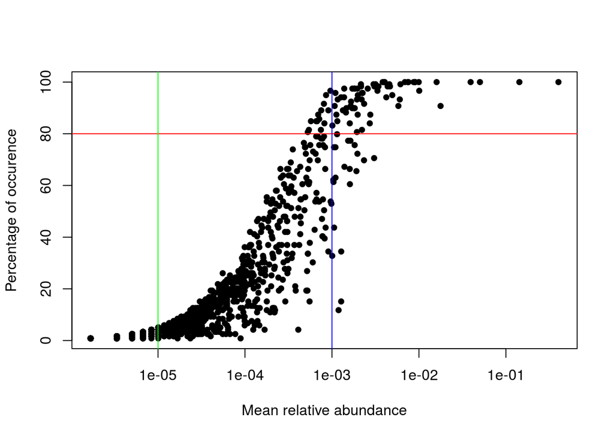

Regionally abundant OTUs (relative abundance over 0.1%):

```
##         mean_rabund perc_occur
## OTU_1   0.401763025  100.00000
## OTU_2   0.142800000  100.00000
## OTU_4   0.050309244  100.00000
## OTU_5   0.039297479  100.00000
## OTU_3   0.017726050   90.75630
## OTU_6   0.015963025  100.00000
## OTU_552 0.010078992   96.63866
## OTU_10  0.009946218  100.00000
## OTU_23  0.009030252  100.00000
## OTU_435 0.009008403  100.00000
## OTU_104 0.008695798  100.00000
## OTU_12  0.007573109  100.00000
## OTU_9   0.007440336  100.00000
## OTU_13  0.006895798  100.00000
## OTU_28  0.006129412   99.15966
## OTU_20  0.006026891   93.27731
## OTU_7   0.005801681   90.75630
## OTU_34  0.004937815   94.95798
## OTU_11  0.004648739   98.31933
## OTU_198 0.004568067   99.15966
## OTU_8   0.004373109   98.31933
## OTU_368 0.004213445   94.11765
## OTU_19  0.004033613  100.00000
## OTU_234 0.004021849  100.00000
## OTU_25  0.003830252  100.00000
## OTU_14  0.003425210   98.31933
## OTU_33  0.003334454   96.63866
## OTU_21  0.003166387   99.15966
## OTU_37  0.003082353   98.31933
## OTU_40  0.003053782   70.58824
## OTU_29  0.003006723   99.15966
## OTU_15  0.002759664   87.39496
## OTU_24  0.002721008   84.03361
## OTU_45  0.002578151   97.47899
## OTU_709 0.002342857   91.59664
## OTU_16  0.002336134   69.74790
## OTU_102 0.002250420   95.79832
## OTU_70  0.002213445   95.79832
## OTU_27  0.002211765   81.51261
```

[output cut: 33 more lines]

```
## OTU_61  0.001191597   11.76471
## OTU_89  0.001164706   93.27731
## OTU_98  0.001152941   84.87395
## OTU_103 0.001144538   79.83193
## OTU_84  0.001124370   87.39496
## OTU_74  0.001099160   63.02521
## OTU_48  0.001097479   74.78992
## OTU_404 0.001095798   95.79832
## OTU_147 0.001073950   90.75630
## OTU_52  0.001058824   43.69748
## OTU_158 0.001055462   74.78992
## OTU_46  0.001042017   61.34454
## OTU_66  0.001036975   62.18487
## OTU_88  0.001011765   83.19328
## OTU_59  0.001006723   32.77311
```

```r
dim(tb16_cc_ss5000_abundant_sorted)
```

```
## [1] 87  2
```

Proportion of regionally abundant OTUs (%):

```
## [1] 7.658451
```

Cosmopolitan OTUs (abundance over 0.1% and occurence in more than 80% of samples):

```
##         mean_rabund perc_occur
## OTU_1   0.401763025  100.00000
## OTU_2   0.142800000  100.00000
## OTU_4   0.050309244  100.00000
## OTU_5   0.039297479  100.00000
## OTU_6   0.015963025  100.00000
## OTU_10  0.009946218  100.00000
## OTU_23  0.009030252  100.00000
## OTU_435 0.009008403  100.00000
## OTU_104 0.008695798  100.00000
## OTU_12  0.007573109  100.00000
## OTU_9   0.007440336  100.00000
## OTU_13  0.006895798  100.00000
## OTU_19  0.004033613  100.00000
## OTU_234 0.004021849  100.00000
## OTU_25  0.003830252  100.00000
## OTU_28  0.006129412   99.15966
## OTU_198 0.004568067   99.15966
## OTU_21  0.003166387   99.15966
## OTU_29  0.003006723   99.15966
## OTU_724 0.002152941   99.15966
## OTU_11  0.004648739   98.31933
## OTU_8   0.004373109   98.31933
## OTU_14  0.003425210   98.31933
## OTU_37  0.003082353   98.31933
## OTU_39  0.002159664   98.31933
## OTU_45  0.002578151   97.47899
## OTU_139 0.001959664   97.47899
## OTU_654 0.001826891   97.47899
## OTU_163 0.001813445   97.47899
## OTU_90  0.001715966   97.47899
## OTU_42  0.001383193   97.47899
## OTU_552 0.010078992   96.63866
## OTU_33  0.003334454   96.63866
## OTU_102 0.002250420   95.79832
## OTU_70  0.002213445   95.79832
## OTU_404 0.001095798   95.79832
## OTU_34  0.004937815   94.95798
## OTU_166 0.001984874   94.95798
## OTU_368 0.004213445   94.11765
```

[output cut: 12 more lines]

```
## OTU_44  0.001826891   89.91597
## OTU_694 0.001794958   89.91597
## OTU_55  0.001705882   89.91597
## OTU_247 0.001465546   89.91597
## OTU_62  0.001336134   89.07563
## OTU_56  0.001448739   88.23529
## OTU_15  0.002759664   87.39496
## OTU_35  0.001976471   87.39496
## OTU_84  0.001124370   87.39496
## OTU_98  0.001152941   84.87395
## OTU_24  0.002721008   84.03361
## OTU_177 0.001603361   84.03361
## OTU_88  0.001011765   83.19328
## OTU_27  0.002211765   81.51261
## OTU_240 0.001936134   80.67227
```

```r
dim(otu_tb16_cc_ss5000_cosmop_sorted)
```

```
## [1] 66  2
```

Proportion of cosmopolitan OTUs (%):

```
## [1] 5.809859
```

Number and proportion (%) of rare OTUs:

```r
dim(otu_tb16_cc_ss5000_rabund_percoccur[otu_tb16_cc_ss5000_rabund_percoccur$mean_rabund < 0.00001 & otu_tb16_cc_ss5000_rabund_percoccur$mean_rabund >0,])
```

```
## [1] 343   2
```

```
## [1] 30.19366
```